# Predição de Votação de Deputados

Luiz Fernando da Silva

26 de novembro de 2018

```r
partition <- createDataPartition(y = data_train$situacao, p=0.75, list=FALSE)
set.seed(9560)
data_train_reparted <- data_train[partition,]
data_test_reparted <- data_train[-partition,]
```

## Há desbalanceamento das classes (isto é, uma classe tem muito mais instâncias que outra)? Em que proporção? Quais efeitos colaterais o desbalanceamento de classes pode causar no classificador?

Como pode-se observar no gráfico abaixo, há um grande desbalanceamento das classes, onde a classe não eleito representa cerca de 87% do total, o que afeta negativamente os algoritmos de predição, já que existem muito mais exemplos de uma classe do que de outra, tornando a predição pouco confiável.

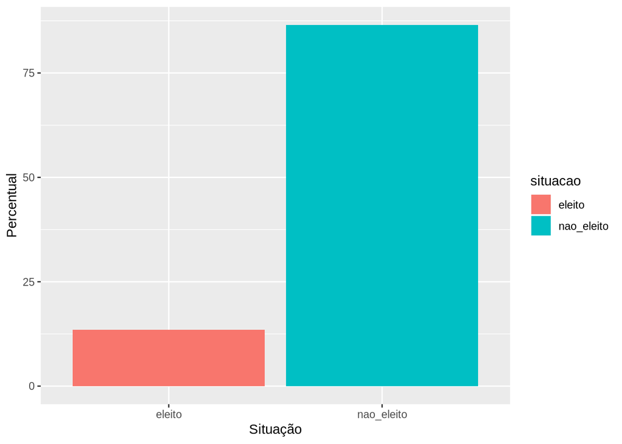

```r
data_train %>%
  group_by(situacao) %>%
  summarise(n_eleitos=(n()/nrow(data_train))*100) %>%
  ggplot(aes(x=situacao, y=n_eleitos, fill=situacao)) + geom_col() + labs(x = "Situação", y = "Percentual")
```

## Como você poderia tratar isso?

Para tratar o problema do desbalanceamento é preciso usar tecnicas de rebalanceamento. Duas das tecnicas de rebalanceamento são o UPSAMPLING e DOWNSAMPLING, no UPSAMPLING serão ciradas amostras aleatórias para que a classe minoritária tenha o mesmo tamanho da classe majoritária, já no DOWNSAMPLING serão selecionadas aleatoriamente amostras da classe majoritária para que a mesma tenha o mesmo tamanho da classe majoritária. O SMOTE é uma técnica hibrida que usa ambas as técnicas mensionadas anteriomente para fazer o rebalanceamenteo das classes.

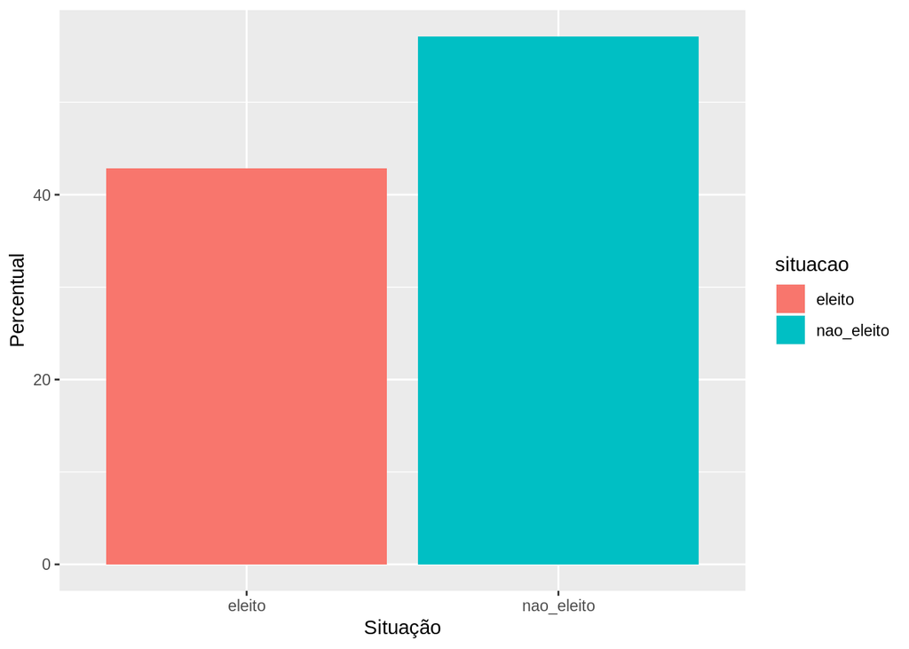

```r
balanced_data <- SMOTE(situacao ~ ., data = data_train_reparted)

balanced_data %>%
  group_by(situacao) %>%
  summarise(n_eleitos=(n()/nrow(balanced_data))*100) %>%
  ggplot(aes(x=situacao, y=n_eleitos, fill=situacao)) + geom_col() + labs(x = "Situação", y = "Percentual")
```

## Treinando: um modelo de KNN, regressão logística, uma árvore de decisão e um modelo de adaboost.

Treinando os modelos para testar o que resultará nas melhores predições

#### Modelo KNN

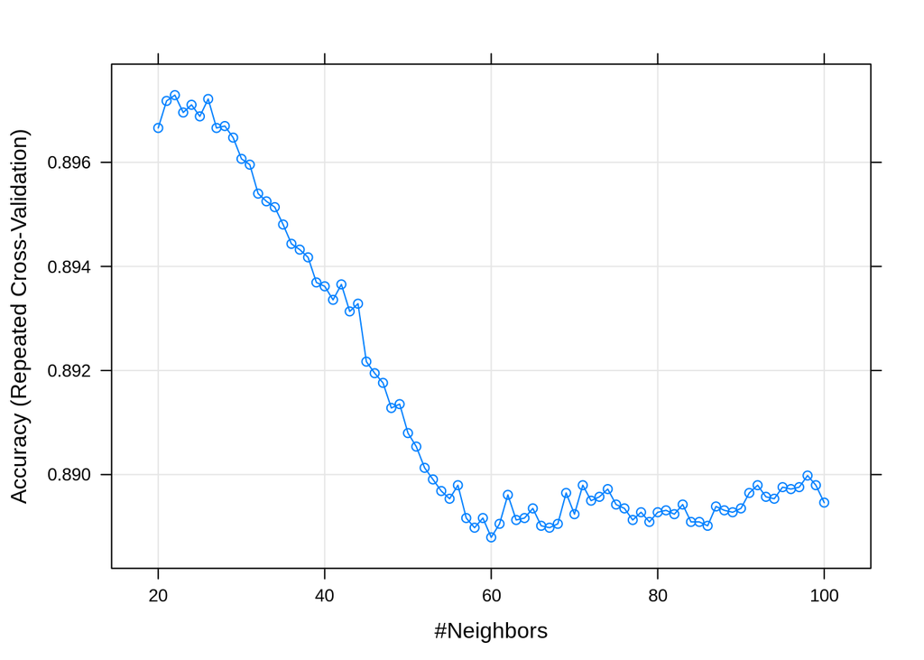

```r
k <- expand.grid(k = seq(20,100, length=81))
fitControl <- trainControl(method = "repeatedcv", number = 10, repeats = 5)

model_knn <- train(situacao ~ .,
                     data = balanced_data,
                     method = "knn",
                     tuneGrid = k,
                     preProc = c("center", "scale"),
                     trControl = fitControl)
plot(model_knn)
```

```r
model_knn
```

```
## k-Nearest Neighbors
##
## 5390 samples
##   13 predictor
##    2 classes: 'eleito', 'nao_eleito'
##
## Pre-processing: centered (13), scaled (13)
## Resampling: Cross-Validated (10 fold, repeated 5 times)
## Summary of sample sizes: 4851, 4851, 4851, 4851, 4851, 4851, ...
## Resampling results across tuning parameters:
##
##   k    Accuracy   Kappa
##    20  0.8966605  0.7923511
##    21  0.8971800  0.7934643
##    22  0.8972913  0.7936613
```

[output cut: 81 more lines]

#### Modelo regressão logistica

```r
model_logistc <- train(situacao ~ .,
                     data = balanced_data,
                     method = "glm",
                     family = "binomial",
                     preProc = c("center", "scale"),
                     trControl = fitControl)
model_logistc
```

```
## Generalized Linear Model
##
## 5390 samples
##   13 predictor
##    2 classes: 'eleito', 'nao_eleito'
##
## Pre-processing: centered (13), scaled (13)
## Resampling: Cross-Validated (10 fold, repeated 5 times)
## Summary of sample sizes: 4851, 4851, 4851, 4851, 4851, 4851, ...
## Resampling results:
##
##   Accuracy   Kappa
##   0.8380705  0.6668741
```

#### Modelo Arvore de decisão

```r
trctrl <- trainControl(method = "repeatedcv", number = 10, repeats = 5)
set.seed(3333)
dtree_fit <- train(situacao ~., data = balanced_data, method = "rpart",
                   trControl = trctrl,
                   tuneLength = 10)
dtree_fit
```

```
## CART
##
## 5390 samples
##   13 predictor
##    2 classes: 'eleito', 'nao_eleito'
##
## No pre-processing
## Resampling: Cross-Validated (10 fold, repeated 5 times)
## Summary of sample sizes: 4851, 4851, 4851, 4851, 4851, 4851, ...
## Resampling results across tuning parameters:
##
##   cp           Accuracy   Kappa
##   0.001154401  0.9065677  0.8107389
##   0.001298701  0.9053061  0.8083202
##   0.001623377  0.9031169  0.8040195
##   0.001731602  0.9022263  0.8022359
##   0.002164502  0.9005566  0.7992352
##   0.002813853  0.8984787  0.7954374
##   0.003030303  0.8971058  0.7929939
##   0.003463203  0.8966605  0.7923310
##   0.003751804  0.8951391  0.7895085
##   0.751082251  0.7016327  0.3207812
##
## Accuracy was used to select the optimal model using the largest value.
## The final value used for the model was cp = 0.001154401.
```

#### Modelo Adaboosting

```r
model_ada <- train(situacao ~ .,
                     data = balanced_data,
                     method = "ada",
                     preProc = c("center", "scale"),
                     trControl = fitControl)
model_ada
```

```
## Boosted Classification Trees
##
## 5390 samples
##   13 predictor
##    2 classes: 'eleito', 'nao_eleito'
##
## Pre-processing: centered (13), scaled (13)
## Resampling: Cross-Validated (10 fold, repeated 5 times)
## Summary of sample sizes: 4851, 4851, 4851, 4851, 4851, 4851, ...
## Resampling results across tuning parameters:
##
##   maxdepth  iter  Accuracy   Kappa
##   1          50   0.8921707  0.7847014
##   1         100   0.8925788  0.7854422
##   1         150   0.8929870  0.7861567
##   2          50   0.8946939  0.7891658
##   2         100   0.8969202  0.7931368
##   2         150   0.8972542  0.7936214
##   3          50   0.8991837  0.7970972
##   3         100   0.9000371  0.7985485
##   3         150   0.9002597  0.7989330
##
## Tuning parameter 'nu' was held constant at a value of 0.1
## Accuracy was used to select the optimal model using the largest value.
## The final values used for the model were iter = 150, maxdepth = 3 and nu
##  = 0.1.
```

## Reporte precision, recall e f-measure no treino e validação. Há uma grande diferença de desempenho no treino/validação?

#### Calculando os valores de CA, EA, CB, EB, onde o significado dos mesmos são respectivamente, corretamente classificados em A, Erroneamente classificados em A, corretamente classificados em B e Erroneamente classificados em B.

### Modelo KNN

```r
data_test_reparted$prediction <- predict(model_knn, data_test_reparted)

CA <- data_test_reparted %>% filter(situacao == "eleito", prediction == "eleito") %>% nrow()
EA <- data_test_reparted %>% filter(situacao == "nao_eleito" , prediction == "eleito") %>% nrow()
CB <- data_test_reparted %>% filter(situacao == "nao_eleito" , prediction == "nao_eleito" ) %>% nrow()
EB <- data_test_reparted %>% filter(situacao == "eleito", prediction == "nao_eleito" ) %>% nrow()
```

#### Calculando o precision, recall e f-measure.

```r
precision <- CA / (CA + EA)
recall <- CA / (CA + EB)
f_measure <- 2 * (precision * recall) / (precision + recall)
precision
```

```
## [1] 0.5099778
```

```r
recall
```

```
## [1] 0.8984375
```

```r
f_measure
```

```
## [1] 0.6506365
```

### Modelo regressão logistica

```r
data_test_reparted$prediction <- predict(model_logistc, data_test_reparted)
CA <- data_test_reparted %>% filter(situacao == "eleito", prediction == "eleito") %>% nrow()
EA <- data_test_reparted %>% filter(situacao == "nao_eleito" , prediction == "eleito") %>% nrow()
CB <- data_test_reparted %>% filter(situacao == "nao_eleito" , prediction == "nao_eleito" ) %>% nrow()
EB <- data_test_reparted %>% filter(situacao == "eleito", prediction == "nao_eleito" ) %>% nrow()
```

#### Calculando o precision, recall e f-measure.

```r
precision <- CA / (CA + EA)
recall <- CA / (CA + EB)
f_measure <- 2 * (precision * recall) / (precision + recall)
precision
```

```
## [1] 0.5958084
```

```r
recall
```

```
## [1] 0.7773438
```

```r
f_measure
```

```
## [1] 0.6745763
```

### Modelo Adaboosting

```r
data_test_reparted$prediction <- predict(model_ada, data_test_reparted)

CA <- data_test_reparted %>% filter(situacao == "eleito", prediction == "eleito") %>% nrow()
EA <- data_test_reparted %>% filter(situacao == "nao_eleito" , prediction == "eleito") %>% nrow()
CB <- data_test_reparted %>% filter(situacao == "nao_eleito" , prediction == "nao_eleito" ) %>% nrow()
EB <- data_test_reparted %>% filter(situacao == "eleito", prediction == "nao_eleito" ) %>% nrow()
```

#### Calculando o precision, recall e f-measure.

```r
precision <- CA / (CA + EA)
recall <- CA / (CA + EB)
f_measure <- 2 * (precision * recall) / (precision + recall)
precision
```

```
## [1] 0.5347222
```

```r
recall
```

```
## [1] 0.9023438
```

```r
f_measure
```

```
## [1] 0.6715116
```

### Modelo Arvore de decisão

```r
data_test_reparted$prediction <- predict(dtree_fit, data_test_reparted)

CA <- data_test_reparted %>% filter(situacao == "eleito", prediction == "eleito") %>% nrow()
EA <- data_test_reparted %>% filter(situacao == "nao_eleito" , prediction == "eleito") %>% nrow()
CB <- data_test_reparted %>% filter(situacao == "nao_eleito" , prediction == "nao_eleito" ) %>% nrow()
EB <- data_test_reparted %>% filter(situacao == "eleito", prediction == "nao_eleito" ) %>% nrow()
```

#### Calculando o precision, recall e f-measure.

```r
precision <- CA / (CA + EA)
recall <- CA / (CA + EB)
f_measure <- 2 * (precision * recall) / (precision + recall)
precision
```

```
## [1] 0.5304569
```

```r
recall
```

```
## [1] 0.8164062
```

```r
f_measure
```

```
## [1] 0.6430769
```

## Interprete as saídas dos modelos. Quais atributos parecem ser mais importantes de acordo com cada modelo?

```r
varImp(model_ada)
```

```
## ROC curve variable importance
##
##                                       Importance
## total_despesa                             100.00
## total_receita                              99.78
## recursos_de_pessoas_juridicas              88.51
## quantidade_fornecedores                    83.47
## quantidade_despesas                        82.76
## quantidade_doadores                        76.58
## quantidade_doacoes                         76.53
## media_receita                              72.56
## recursos_de_pessoas_fisicas                72.08
## media_despesa                              43.27
## recursos_proprios                          36.41
## recursos_de_outros_candidatos.comites      18.71
## recursos_de_partido_politico                0.00
```

```r
varImp(model_knn)
```

```
## ROC curve variable importance
##
##                                       Importance
## total_despesa                             100.00
## total_receita                              99.78
## recursos_de_pessoas_juridicas              88.51
## quantidade_fornecedores                    83.47
## quantidade_despesas                        82.76
## quantidade_doadores                        76.58
## quantidade_doacoes                         76.53
## media_receita                              72.56
## recursos_de_pessoas_fisicas                72.08
## media_despesa                              43.27
## recursos_proprios                          36.41
## recursos_de_outros_candidatos.comites      18.71
## recursos_de_partido_politico                0.00
```

```r
varImp(dtree_fit)
```

```
## rpart variable importance
##
##                                       Overall
## total_receita                         100.000
## total_despesa                          98.939
## recursos_de_pessoas_juridicas          78.864
## quantidade_despesas                    67.587
## quantidade_fornecedores                65.829
## recursos_de_pessoas_fisicas             7.546
## recursos_proprios                       5.559
## quantidade_doadores                     5.139
## media_despesa                           5.016
## quantidade_doacoes                      4.602
## media_receita                           4.129
## recursos_de_outros_candidatos.comites   1.352
## recursos_de_partido_politico            0.000
```

```r
varImp(model_logistc)
```

```
## glm variable importance
##
##                                       Overall
## recursos_de_pessoas_fisicas           100.000
## recursos_de_pessoas_juridicas          50.793
## media_receita                          45.332
## total_despesa                          35.404
## recursos_de_outros_candidatos.comites  35.152
## total_receita                          33.589
## recursos_proprios                      17.386
## quantidade_doadores                    12.632
## quantidade_doacoes                      8.374
## quantidade_fornecedores                 3.989
## media_despesa                           1.752
## quantidade_despesas                     0.000
```

## Envie seus melhores modelos à competição do Kaggle. Faça pelo menos uma submissão.

```r
prediction <- predict(model_ada, data_test)

data_out <- data.frame(ID = data_test$sequencial_candidato, Predicted = prediction)
data_out$ID <-as.character(data_out$ID)
data_out %>% write_csv(path = "data/out2.csv")
```